# Stress

# Recall: stress tensor

${}$

$$ \mathbf{S} = \begin{bmatrix} S_{11} & S_{12} & S_{13} \\ S_{21} & S_{22} & S_{23} \\ S_{31} & S_{32} & S_{33} \end{bmatrix} $$

Due to **conservation of angular momentum**: $S_{12} = S_{21}, S_{13} = S_{31}$ and $S_{32} = S_{23}$ .

$$ \mathbf{S} = \begin{bmatrix} S_{11} & S_{12} & S_{13} \\ S_{12} & S_{22} & S_{23} \\ S_{13} & S_{23} & S_{33} \end{bmatrix} $$

# Principle stresses and directions

${}$

$$\mathbf{S}' = \mathbf{Q}^{-1} \mathbf{S Q}$$

$$ \mathbf{S}' = \begin{bmatrix} S_1 & 0 & 0 \\ 0 & S_2 & 0 \\ 0 & 0 & S_3 \end{bmatrix} $$

with $S_1 \gt S_2 \gt S_3$ where the $S_i$'s are the eigenvalues of $\mathbf{S}$

$$ \mathbf{Q} = [ \vec{v}_1 \; \vert \; \vec{v}_2 \; \vert \; \vec{v}_3 ] $$

where $\vec{v}_1$ is the eigenvector corresponding to $S_1$, $\vec{v}_2$ is the eigenvector corresponding to $S_2$, and $\vec{v}_3$ is the eigenvector corresponding to $S_3$.

# Example

Determine the principle stresses and directions given:

$$ \mathbf{S} = \begin{bmatrix} 1 & 0 & 0 \\ 0 & 3 & -1 \\ 0 & -1 & 3 \end{bmatrix} $$

$$ S_1 = 4, \quad S_2 = 2, \quad S_3 = 1 $$

$$ \mathbf{Q} = [ \vec{v}_1 \; \vert \; \vec{v}_2 \; \vert \; \vec{v}_3 ] = \begin{bmatrix} 0 & 0 & 1 \\ -1 & 1 & 0 \\ 1 & 1 & 0 \end{bmatrix} $$

# Conservation of linear momentum

\begin{align} \rho \frac{\partial^2 u_1}{\partial t^2} &= \frac{\partial S_{11}}{\partial x_1} + \frac{\partial S_{12}}{\partial x_2} + \frac{\partial S_{13}}{\partial x_3} + \rho b_1 \\ \rho \frac{\partial^2 u_2}{\partial t^2} &= \frac{\partial S_{12}}{\partial x_1} + \frac{\partial S_{22}}{\partial x_2} + \frac{\partial S_{23}}{\partial x_3} + \rho b_2 \\ \rho \frac{\partial^2 u_1}{\partial t^2} &= \frac{\partial S_{13}}{\partial x_1} + \frac{\partial S_{23}}{\partial x_2} + \frac{\partial S_{33}}{\partial x_3} + \rho b_3 \end{align}

# Principle stresses and directions in the earth

[figure not shown]

```python
import IPython
IPython.display.Image(url='http://www.clker.com/cliparts/3/1/b/a/11971488211294199438barretr_Earth.svg.med.png', width=300, embed=True)
```

# Idealized half-space

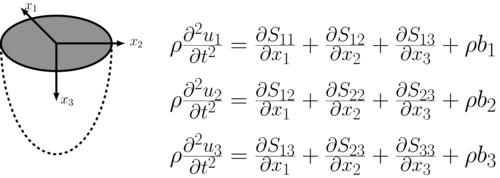

```python
%%tikz --scale 1.0 --size 500,500 -f png
\fill[color=gray] (0,0) ellipse [x radius=2, y radius=1];
\draw[line width=2] (0,0) ellipse [x radius=2, y radius=1];
\draw[line width=2, dashed] (2,0) arc  (0:-180:2 and 4);
\draw[line width=2, -latex] (0,0) -- (0,-2.1) node[right,text width=2] {\Large $x_3$};
\draw[line width=2, -latex] (0,0) -- (-1.3,1.3) node[right,text width=2] {\Large $x_1$};
\draw[line width=2, -latex] (0,0) -- (2.5,0) node[right,text width=3] {\Large $x_2$};
\node at (10,0)  {\Huge $\rho \frac{\partial^2 u_1}{\partial t^2} = \frac{\partial S_{11}}{\partial x_1} +\frac{\partial S_{12}}{\partial x_2} + \frac{\partial S_{13}}{\partial x_3} + \rho b_1$};
\node at (10,-2) {\Huge $\rho \frac{\partial^2 u_2}{\partial t^2} = \frac{\partial S_{12}}{\partial x_1} +\frac{\partial S_{22}}{\partial x_2} + \frac{\partial S_{23}}{\partial x_3} + \rho b_2$};
\node at (10,-4) {\Huge $\rho \frac{\partial^2 u_3}{\partial t^2} = \frac{\partial S_{13}}{\partial x_1} +\frac{\partial S_{23}}{\partial x_2} + \frac{\partial S_{33}}{\partial x_3} + \rho b_3$};
```

$S_{33} = S_v$ must be a principle stress!

## Four parameters needed to describe state-of-stress in the earth

- $S_\mbox{v}$ - vertical stress magnitude
- $S_{\mbox{Hmax}}$ - maximum horizontal principle stress magnitude
- $S_\mbox{Hmin}$ - minimum horizontal principle stress magnitude
- One horizontal principle direction, usually the direction associated with $S_\mbox{Hmax}$

[figure not shown]